# Listening to Customers is Not Enough to Uncover Their Needs

CEO

Decision-making

Customer value

Don’t Confuse Salience with Importance.

## FOODCO’s Strategy Dilemma

The book **[FOCUS](https://focus-book.net/)** narrates the story of FOODCO, a lunch-focused restaurant chain with 22 locations in a major metropolitan city.

During a strategy planning meeting, FOODCO’s CEO says, *“We sell over a million meals a year because of our extensive menu of offerings and high quality. Last week, two customers from a restaurant thanked me for the expanded menu selection and high-quality food. We need to emphasize these benefits to improve customer value and sales.”*

On the face of it, FOODCO’s CEO seemed to be doing all the right things. He took the time to visit his restaurant, interact with the customers during service hours and talk to them about how they felt about FOODCO’s offering. So if the customers told him they liked the menu selection and high-quality food, it seems reasonable to assume that FOODCO’s strategy should be to focus on these areas right?

Not always right.

FOODCO’s CEO bases his proposed strategy on **salience**—he easily recalls two benefits that customers have mentioned in conversations with him.The salience of a strategic area is measured by the probability with which a benefit is recalled and mentioned by a customer. In everyday life, salience is the extent to which some facts and perceptual elements are prominent and top-of-mind as well as easier to recall, remember, and imagine than others.

In this blog, we walk through the technicalities behind salience and importance, to avoid falling for the salience trap while formulating strategy.

## Capturing Salience from Customer Feedback

Executives frequently talk to stakeholders like customers, employees, suppliers, and peers. They then use portions of the conversations they recall in order to formulate strategy.

As a former chef, FOODCO’s owner loved to visit the restaurants when customer were dining and ask them about the quality of the food and the menu selection. After obtaining a transcript of the interviews, one could perform natural language processing to capture salience from customer feedback. The wordcloud below visually depicts the most frequently occurring themes in the conversations .

[interactive chart not shown]

The visualization shows that the quality of the menu, tasty food, selection and of items were popular themes in the conversation. **You can scroll over the words to see how frequently they occurred in the conversations**. The visualization also shows that the minutes of wait time and need to reduce the menu came up as popular themes in the conversations. The FOODCO owner recalled the extensive menu and high quality food more than other items. Certain issues resonate with executives due to their own experiences. Since the FOODCO owner is a former chef. When customers talk about food variety and quality, it confirms the restaurant owner’s pre-existing notions (also called confirmation bias).

More formally, we can obtain salience by calculating the percent occurrence of the most frequent words in the conversations. The figure below lists the most frequent words from the interviews. The most frequent Words are shown below in the bar plot. As we can see, **quality** occurs most frequently constituting **30%** of the sum of the most frequently occurring five words, followed by **menu(26%)**, and **tasty(15)**. This figure further illustrates why FOODCO’s CEO argued that the strategy should be based on these items.

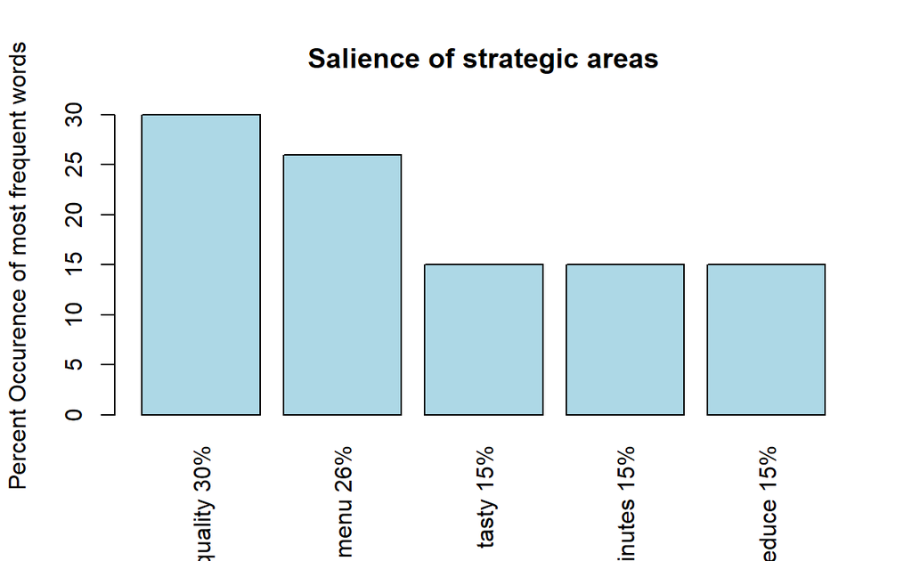

Simply basing strategy on informal stakeholder input can be heavily biased for several reasons:

- Individual customers mention issues that are not representative of the customer base.
- Certain issues resonate with executives due to their own experiences. When customers talk about food variety and quality, it confirms the restaurant owner’s pre-existing notions as a chef.
- Executives seek out unstructured conversations with stakeholders who support their pre-existing views. Due to selection bias, they elicit only a narrow selection of views rather than a complete spectrum of views; this reinforces already salient information and ignores novel insights. The CEO of a company in the oilfield services business states: “Safety is critical to our company’s mission—we are very interested in listening to clients so we can learn more about their safety needs.”

## Understanding the Importance of Customer Needs

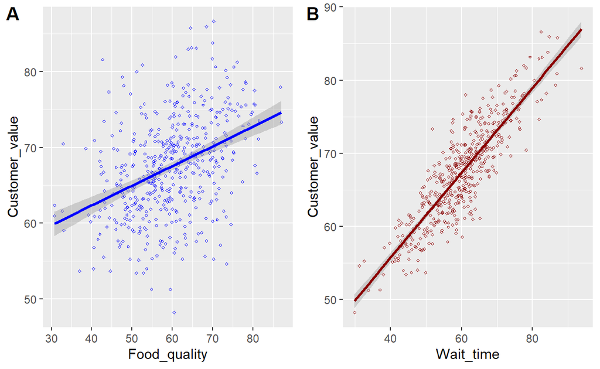

## How FOODCO Based Its Strategy on Importance

To determine the importance of strategic areas, the restaurant chain conducts a customer study measuring satisfaction with each area as well as overall satisfaction. The strength of association between strategic area satisfaction and overall satisfaction represents the importance of each customer benefit(Figure 1).

A comparison of Panel A and B in Figure 1 shows that the strategic areas important for customers are not the areas salient to the restaurant-chain owner. Decades of research shows a weak to non-existent correlation between the salience and importance of customer benefits.

He focused on the many different menu items he believed would preserve FOODCO’s “high quality”—freshly prepared sandwiches, soups, and salads. Yet, customer surveys showed that customers wanted a fast dining experience with a short wait time, a simple menu with few items, ample parking, and a bill lower than $12 per meal, drinks included.

## Conclusion: Listening to Customers is Not Enough to Develop a Strategy

A firm’s value proposition and customer value equation should be based on benefits important to its customers and strategic areas in which the customers perceive the firm’s performance as being better than its competitors. Many firms focus only on salient customer benefits through “listening sessions” which risk ignoring truly important benefits. This is a mistake.

Many salient benefits may not actually be important to customers, and vice versa. Due to its ease and higher probability of recall, salient information is often incorrectly perceived as being important. Many times, people incorrectly emphasize salient information in their decision-making. The way a job candidate dresses may be salient to an interviewer but it may be completely unimportant for job performance.

To arrive at a focused and customer-based strategy, executives need to base their strategy on **importance**. The importance of a strategic area is the strength of the association between the strategic area and a desired outcome, such as overall satisfaction, word-of-mouth, or purchase behavior. Many benefits are important to customers, even though they may not be salient.Customers who have read about a local plane crash may consider safety to be a salient issue. But when traveling on a long-haul flight, they may actually find benefits like comfort (seating, legroom, blankets, and pillows) and pricing (tickets, free luggage, and carry-ons allowed) to be the most important drivers of their overall satisfaction with the trip.

To counteract the damaging effects of salience and prioritize strategy areas based on importance, executives must first conduct a rigorous analysis. They must clearly define their desired outcome and a set of critical inputs. The inputs’ importance must be calculated based on how strongly each is linked to the desired outcome. The process involves linking performance in different strategy areas to the outcome while statistically controlling for confounding extraneous factors.

This brief describes the correct approach to measuring the importance of customer benefits and evaluating a firm’s performance as perceived by customers.